# Zadania 8

Szymon Szrajer

20 05 2021

## Zadanie 1

**Hipoteza robocza:** Dieta i ćwiczenia fizyczne mają wpływ na poziom tłuszczu w ciele.  
**Hipoteza zerowa:** Dieta i ćwiczenia fizyczne nie mają wpływu na poziom tłuszczu w ciele.  
**Hipoteza alternatywna:** Dieta i ćwiczenia fizyczne mają wpływ na poziom tłuszczu w ciele.  
**Model:** Y=µ+D+E+DE+e  
**Założenia teoretyczne:** Normalność rozkładu wartości resztowych, liniowość zależności, homogeniczność wariancji, niezależność obserwacji.

```r
fat <- read.delim(file = "Fat_v1.txt", header = T)

fat$FM <- fat$TM - fat$LM
fat$FC <- (fat$FM * 100)/ fat$TM


 fat %>% group_by(D, E)  %>%
  summarize(mean = mean(FC), median = median(FC),
            maximum = max(FC), minimum = min(FC), sd = sd(FC), N = length(FC))
```

```
## # A tibble: 4 x 8
## # Groups:   D [2]
##       D     E  mean median maximum minimum    sd     N
##   <int> <int> <dbl>  <dbl>   <dbl>   <dbl> <dbl> <int>
## 1     0     0  22.8   22.0    26.7   19.9   2.24    10
## 2     0     1  18.4   18.4    20.9   14.5   1.92    10
## 3     1     0  22.4   22.5    28.2   16.8   2.97    10
## 4     1     1  12.4   12.9    16.6    7.53  2.47    10
```

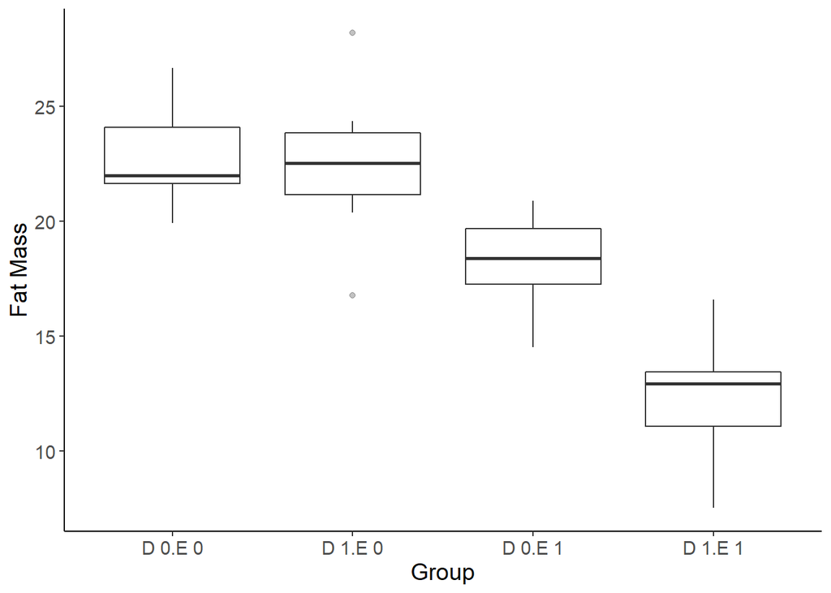

```r
 fat$D <- as.factor(fat$D)
 fat$E <- as.factor(fat$E)

 levels(fat$D) <- c("D 0","D 1")
 levels(fat$E) <- c("E 0","E 1")

 ggplot(fat, aes(x = interaction(D, E),y=FC)) +
  geom_boxplot(alpha = 0.3) + theme_classic() +
  theme(text = element_text(size = 14)) +
  labs(x = "Group", y = "Fat Mass")
```

Rozdkład poza grupą D0E0 jest symetryczny, nie ma dużych outlayerów.

```r
 levels(fat$D) <- c("0", "1")
 levels(fat$E) <- c("0", "1")

 fat$D <- as.numeric(levels(fat$D)[fat$D])
 fat$E <- as.numeric(levels(fat$E)[fat$E])
```

**ANOVA:**

```r
  fatlm <- lm(FC ~ D + E + D:E, data = fat)
```

**Założenia:**

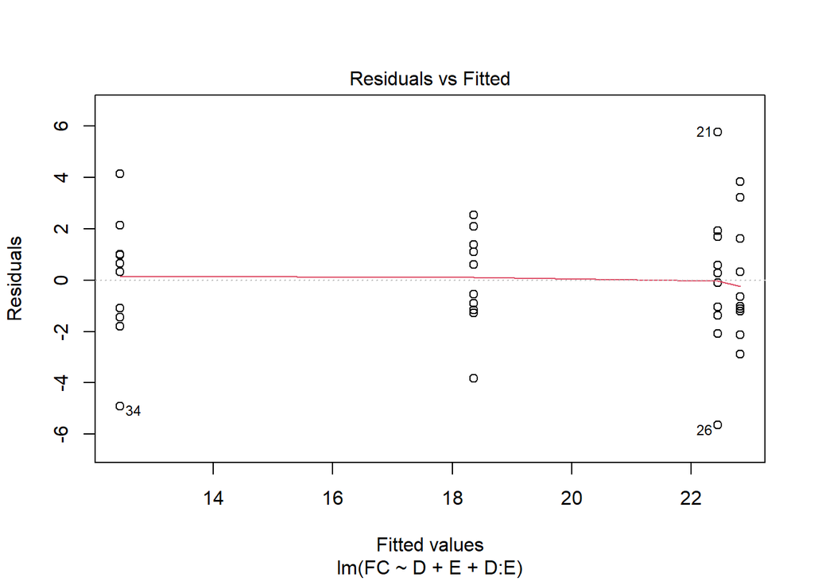

```r
plot(fatlm,1)
```

Wariancje są równe oraz symetrycznie położone względem zera.

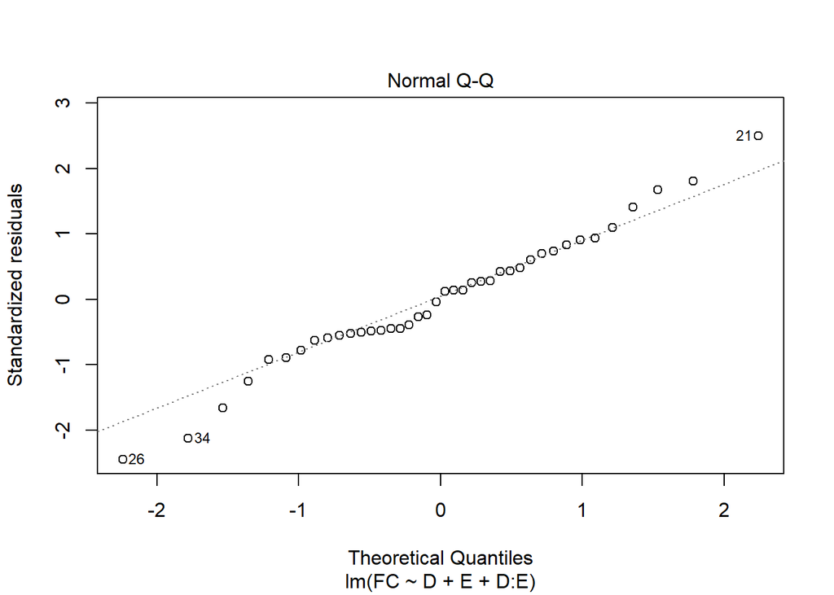

```r
  plot(fatlm,2)
```

Rozkład resztowy jest normalny.

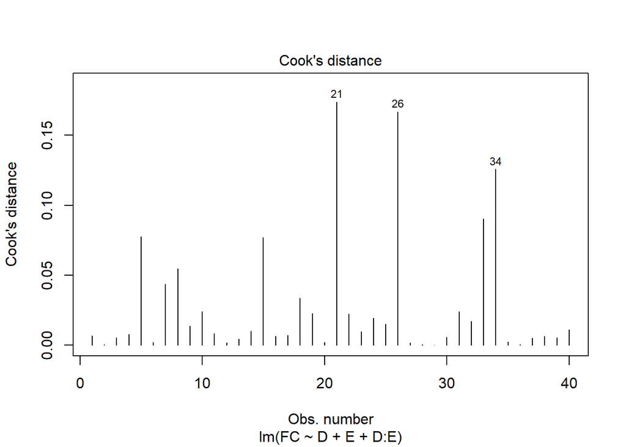

```r
  plot(fatlm,4)
```

Outlayery mają znikomy wpływ na przebieg analizy.

**Wyniki i wnioski**:

```r
  summary(fatlm)
```

```
##
## Call:
## lm(formula = FC ~ D + E + D:E, data = fat)
##
## Residuals:
##     Min      1Q  Median      3Q     Max
## -5.6543 -1.2196  0.0836  1.4446  5.7717
##
## Coefficients:
##             Estimate Std. Error t value Pr(>|t|)
## (Intercept)  22.8150     0.7689  29.671  < 2e-16 ***
## D            -0.3724     1.0874  -0.342 0.733967
## E            -4.4558     1.0874  -4.098 0.000227 ***
## D:E          -5.5484     1.5379  -3.608 0.000930 ***
## ---
## Signif. codes:  0 '***' 0.001 '**' 0.01 '*' 0.05 '.' 0.1 ' ' 1
##
## Residual standard error: 2.432 on 36 degrees of freedom
## Multiple R-squared:  0.7665, Adjusted R-squared:  0.747
## F-statistic: 39.39 on 3 and 36 DF,  p-value: 1.836e-11
```

Sama zmiana diety nie ma wpływu na procentową zawartość tłuszczu w ciele. Natomiast zarówno ćwiczenia przy standardowej diecie oraz połączenie ćwiczeń ze zmianą diety mają istotny wpływ na zawartość tłuszczu w ciele.

```r
  anova(fatlm)
```

```
## Analysis of Variance Table
##
## Response: FC
##           Df Sum Sq Mean Sq F value    Pr(>F)
## D          1  99.01   99.01  16.746 0.0002301 ***
## E          1 522.73  522.73  88.411 3.136e-11 ***
## D:E        1  76.96   76.96  13.017 0.0009301 ***
## Residuals 36 212.85    5.91
## ---
## Signif. codes:  0 '***' 0.001 '**' 0.01 '*' 0.05 '.' 0.1 ' ' 1
```

Wyniki we wszystkich trzech grupach, tzn. w grupie diety, ćwiczeń oraz diety z ćwiczeniami dają wynik istotny statystycznie.

```r
  emmeans(fatlm, pairwise ~ D:E, adjust = "tukey")
```

```
## $emmeans
##  D E emmean    SE df lower.CL upper.CL
##  0 0   22.8 0.769 36     21.3     24.4
##  1 0   22.4 0.769 36     20.9     24.0
##  0 1   18.4 0.769 36     16.8     19.9
##  1 1   12.4 0.769 36     10.9     14.0
##
## Confidence level used: 0.95
##
## $contrasts
##  contrast  estimate   SE df t.ratio p.value
##  0 0 - 1 0    0.372 1.09 36 0.342   0.9860
##  0 0 - 0 1    4.456 1.09 36 4.098   0.0012
##  0 0 - 1 1   10.377 1.09 36 9.542   <.0001
##  1 0 - 0 1    4.083 1.09 36 3.755   0.0033
##  1 0 - 1 1   10.004 1.09 36 9.200   <.0001
##  0 1 - 1 1    5.921 1.09 36 5.445   <.0001
##
## P value adjustment: tukey method for comparing a family of 4 estimates
```

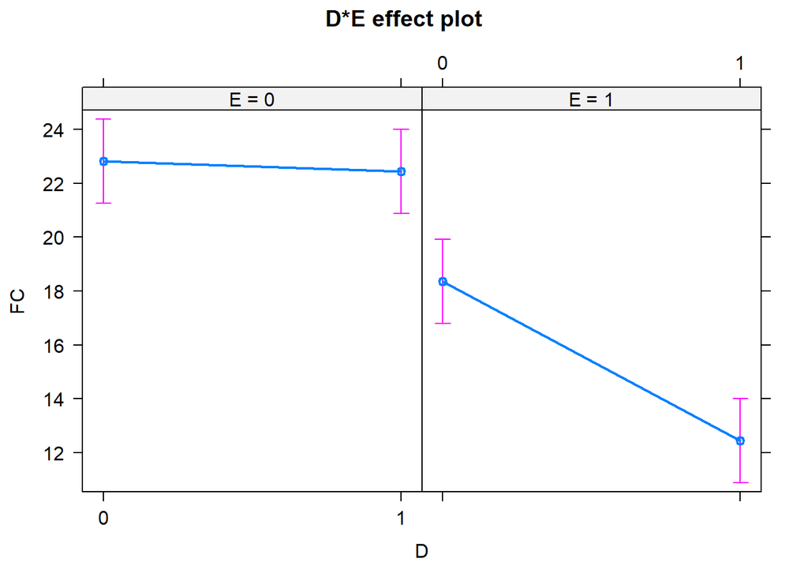

```r
fat$D <- as.factor(fat$D)
fat$E <- as.factor(fat$E)
fat_lm <- lm(FC ~ D + E + D:E, data = fat)
plot(allEffects(fat_lm))
```

Wyłącznie zmiana diety na eksperymentalną nie ma wpływu na procentową zawartość tłuszczu w ciele. Na procentową zawartość tłuszczu w ciele mają wpływ ćwiczenia, zarówno w grupie z samymi ćwiczeniami, jak i ćwiczeniami połączonymi z dietą.

## Zadanie 2

```r
crowy <- read.delim(file = "Cows.txt", header = T, stringsAsFactors = T)
```

**Hipoteza robocza:** Rasa i wiek krowy mają wpływ na zawartość tłuszczu maślanego w mleku.  
**Hipoteza zerowa:** Rasa i wiek krowy nie mają wpływu na zawartość tłuszczu maślanego w mleku.  
**Hipoteza alternatywna:** Rasa i wiek krowy mają wpływ na zawartość tłuszczu maślanego w mleku.  
——————————————————————————————————–  
**Hipoteza robocza:** Rasa krowy ma wpływ na zawartość tłuszczu maślanego w mleku.  
**Hipoteza zerowa:** Rasa krowy nie ma wpływu na zawartość tłuszczu maślanego w mleku.  
**Hipoteza alternatywna:** Rasa krowy ma wpływ na zawartość tłuszczu maślanego w mleku.  
——————————————————————————————————–  
**Hipoteza robocza:** Wiek krowy ma wpływ na zawartość tłuszczu maślanego w mleku.  
**Hipoteza zerowa:** Wiek krowy nie ma wpływu na zawartość tłuszczu maślanego w mleku.  
**Hipoteza alternatywna:** Wiek krowy ma wpływ na zawartość tłuszczu maślanego w mleku.  
——————————————————————————————————–  
**Model:** Butterfat = µ + Breed + Age + BreedAge + e  
**Założenia teoretyczne:** Normalność rozkładu wartości resztowych, liniowość zależności, homogeniczność wariancji, niezależność obserwacji.

```r
crowy %>% group_by(Breed, Age) %>%
  summarise(mean = mean(Butterfat), median = median(Butterfat),
            maximum = max(Butterfat), minimum = min(Butterfat), sd = sd(Butterfat), N =  length(Butterfat))
```

```
## # A tibble: 10 x 8
## # Groups:   Breed [5]
##    Breed    Age     mean median maximum minimum    sd     N
##    <fct>    <fct>  <dbl>  <dbl>   <dbl>   <dbl> <dbl> <int>
##  1 Ayrshire 2year   3.97   3.97    4.37    3.53 0.252    10
##  2 Ayrshire Mature  4.15   4.18    4.44    3.74 0.246    10
##  3 Canadian 2year   4.49   4.31    5.24    3.98 0.457    10
##  4 Canadian Mature  4.39   4.42    4.85    3.92 0.261    10
##  5 Guernsey 2year   4.90   4.92    5.97    3.88 0.566    10
##  6 Guernsey Mature  5.00   4.9     5.75    4.54 0.408    10
##  7 Holstein 2year   3.66   3.60    3.95    3.38 0.213    10
##  8 Holstein Mature  3.68   3.58    4.43    3.3  0.310    10
##  9 Jersey   2year   5.13   4.99    6.45    4.22 0.667    10
## 10 Jersey   Mature  5.45   5.24    6.55    4.8  0.506    10
```

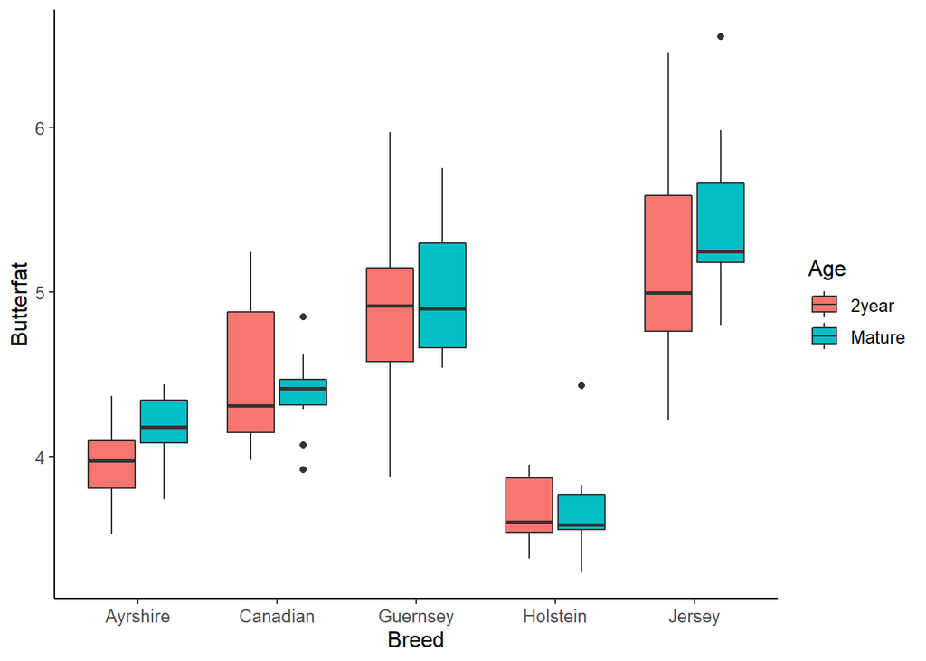

```r
crowy_pl <- ggplot(data = crowy, mapping = aes(x = Breed, y = Butterfat , fill = Age)) + geom_boxplot() + theme_classic() + theme(text = element_text(size = 12))
crowy_pl
```

**ANOVA:**

```r
crowy_lm <- lm(Butterfat ~ Breed + Age + Breed:Age, data = crowy)
```

**Założenia:**

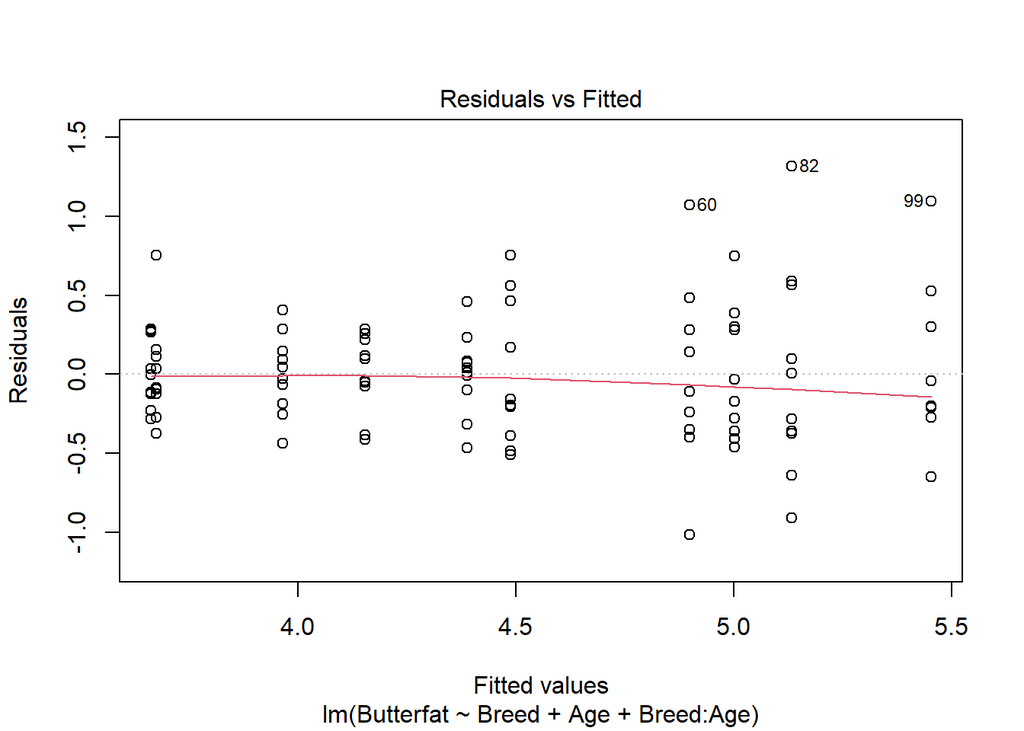

```r
plot(crowy_lm,1)
```

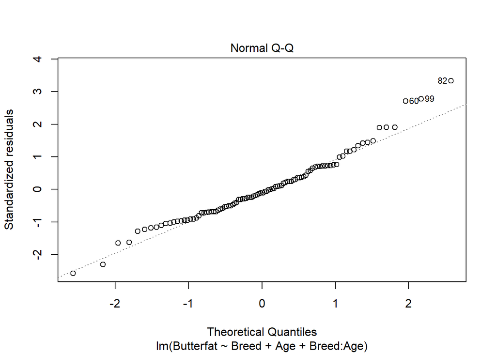

```r
plot(crowy_lm,2)
```

Rozkład resztowy jest normalny.

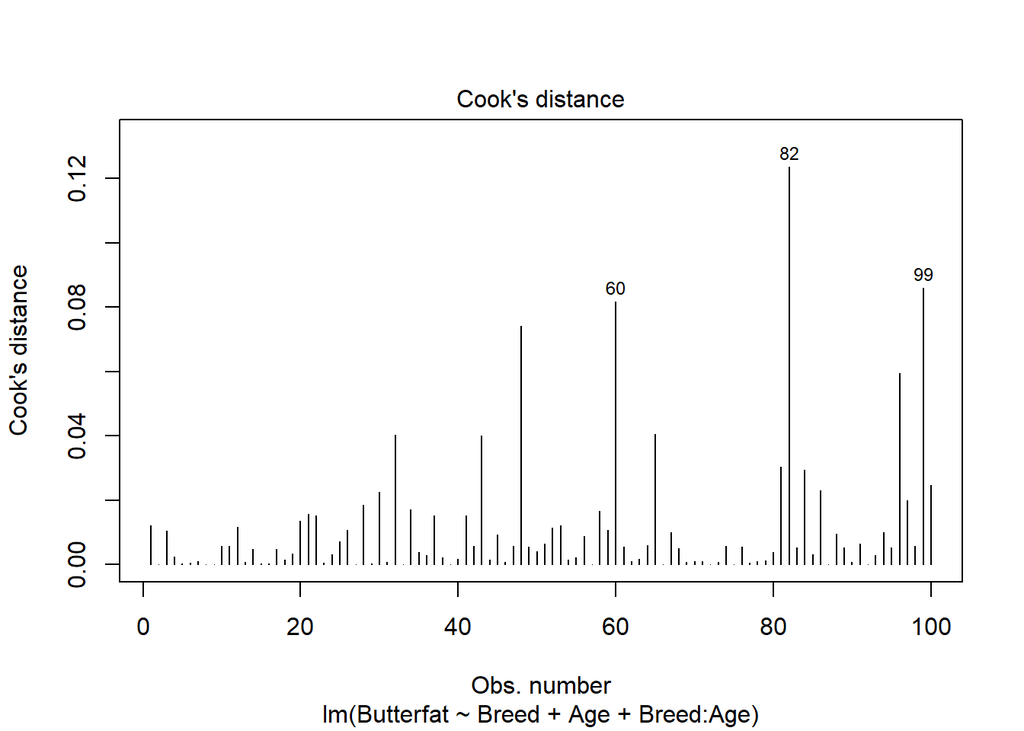

```r
plot(crowy_lm,4)
```

Outlayery mają znikomy wpływ na przebieg analizy.

**Wyniki i wnioski**:

```r
  summary(crowy_lm)
```

```
##
## Call:
## lm(formula = Butterfat ~ Breed + Age + Breed:Age, data = crowy)
##
## Residuals:
##     Min      1Q  Median      3Q     Max
## -1.0190 -0.2720 -0.0430  0.2372  1.3170
##
## Coefficients:
##                         Estimate Std. Error t value Pr(>|t|)
## (Intercept)               3.9660     0.1316  30.143  < 2e-16 ***
## BreedCanadian             0.5220     0.1861   2.805  0.00616 **
## BreedGuernsey             0.9330     0.1861   5.014 2.65e-06 ***
## BreedHolstein            -0.3030     0.1861  -1.628  0.10693
## BreedJersey               1.1670     0.1861   6.272 1.22e-08 ***
## AgeMature                 0.1880     0.1861   1.010  0.31503
## BreedCanadian:AgeMature  -0.2870     0.2631  -1.091  0.27834
## BreedGuernsey:AgeMature  -0.0860     0.2631  -0.327  0.74457
## BreedHolstein:AgeMature  -0.1750     0.2631  -0.665  0.50773
## BreedJersey:AgeMature     0.1310     0.2631   0.498  0.61982
## ---
## Signif. codes:  0 '***' 0.001 '**' 0.01 '*' 0.05 '.' 0.1 ' ' 1
##
## Residual standard error: 0.4161 on 90 degrees of freedom
## Multiple R-squared:  0.6926, Adjusted R-squared:  0.6619
## F-statistic: 22.53 on 9 and 90 DF,  p-value: < 2.2e-16
```

```r
  anova(crowy_lm)
```

```
## Analysis of Variance Table
##
## Response: Butterfat
##           Df Sum Sq Mean Sq F value Pr(>F)
## Breed      4 34.321  8.5803 49.5651 <2e-16 ***
## Age        1  0.274  0.2735  1.5801 0.2120
## Breed:Age  4  0.514  0.1285  0.7421 0.5658
## Residuals 90 15.580  0.1731
## ---
## Signif. codes:  0 '***' 0.001 '**' 0.01 '*' 0.05 '.' 0.1 ' ' 1
```

Tylko rasa ma istotny wpływ na zawartość tłuszczu w mleku.

```r
emmeans(crowy_lm, pairwise ~ Breed, adjust = "tukey")
```

```
## NOTE: Results may be misleading due to involvement in interactions
```

```
## $emmeans
##  Breed    emmean    SE df lower.CL upper.CL
##  Ayrshire   4.06 0.093 90     3.88     4.24
##  Canadian   4.44 0.093 90     4.25     4.62
##  Guernsey   4.95 0.093 90     4.77     5.13
##  Holstein   3.67 0.093 90     3.48     3.85
##  Jersey     5.29 0.093 90     5.11     5.48
##
## Results are averaged over the levels of: Age
## Confidence level used: 0.95
##
## $contrasts
##  contrast            estimate    SE df t.ratio p.value
##  Ayrshire - Canadian   -0.378 0.132 90  -2.877 0.0392
##  Ayrshire - Guernsey   -0.890 0.132 90  -6.764 <.0001
##  Ayrshire - Holstein    0.391 0.132 90   2.968 0.0307
##  Ayrshire - Jersey     -1.232 0.132 90  -9.367 <.0001
##  Canadian - Guernsey   -0.511 0.132 90  -3.888 0.0018
##  Canadian - Holstein    0.769 0.132 90   5.845 <.0001
##  Canadian - Jersey     -0.854 0.132 90  -6.491 <.0001
##  Guernsey - Holstein    1.280 0.132 90   9.732 <.0001
##  Guernsey - Jersey     -0.343 0.132 90  -2.603 0.0783
##  Holstein - Jersey     -1.623 0.132 90 -12.335 <.0001
##
## Results are averaged over the levels of: Age
## P value adjustment: tukey method for comparing a family of 5 estimates
```

Istotne różnice występują między wszystkimi rasami poza Guernsey - Jersey.

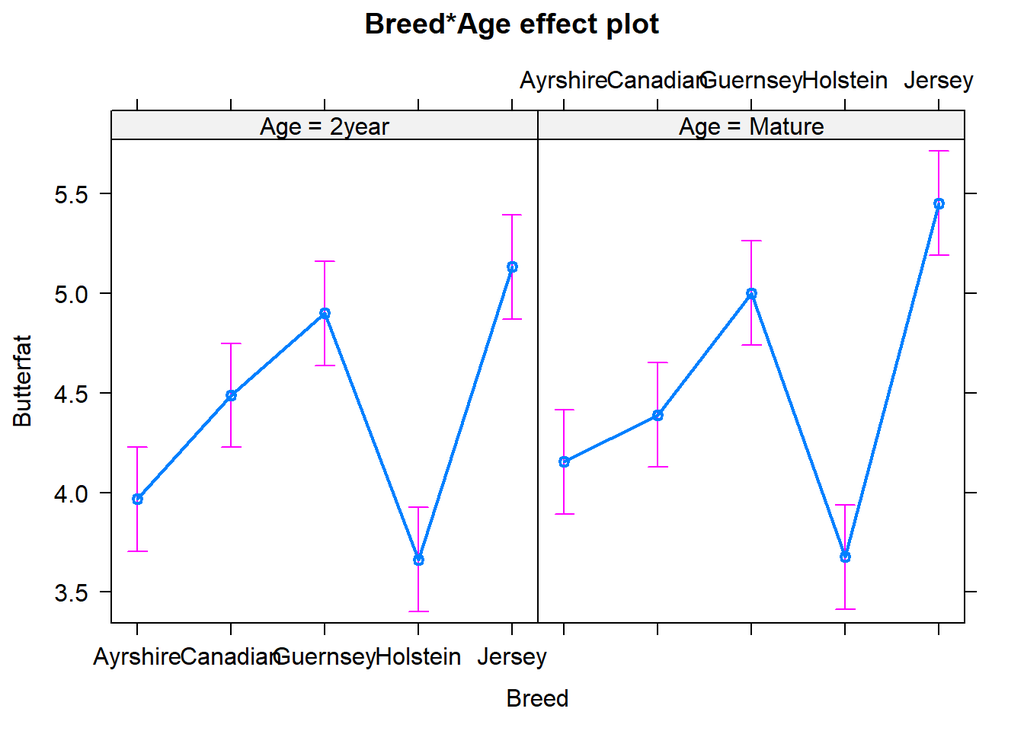

```r
plot(allEffects(crowy_lm), cex.lab=0.4, cex.axis=0.4)
```

Wyłącznie rasa krów ma statystycznie istotny wpływ na zawartość tłuszczu w mleku. Nie ma na nią wpływu wiek, ani interakcja wiek+rasa.